# 3_Data_Wrangling_and_Visualization

**Coursebook: Data Wrangling and Visualization**

- Bagian 3 Audit Analytics untuk Bank Rakyat Indonesia
- Durasi: 7 Jam
- *Last Updated*: December 2023
- *Coursebook* ini disusun dan dikurasi oleh tim produk dan instruktur dari [Algoritma Data Science School](https://algorit.ma/)

# Latar Belakang

*Coursebook* ini merupakan bagian dari **BRI Audit Analytics** yang disiapkan oleh [Algoritma](https://algorit.ma). *Coursebook* ini ditujukan hanya untuk khalayak terbatas, yaitu individu dan organisasi yang menerima *coursebook* ini langsung dari organisasi pelatihan. Tidak boleh direproduksi, didistribusikan, diterjemahkan, atau diadaptasi dalam bentuk apapun di luar individu dan organisasi ini tanpa izin.

Algoritma adalah pusat pendidikan *data science* yang berbasis di Jakarta. Kami menyelenggarakan *workshop* dan program pelatihan untuk membantu para profesional dan mahasiswa dalam menguasai berbagai sub-bidang *data science* yaitu: *data visualization, machine learning,* statistik, dan lain sebagainya.

# Tujuan Pelatihan

Coursebook ini berfokus pada:

- Stacking and Unstacking
- Reproducible Environment
- Working with MultiIndex DataFrames
- Reshaping your DataFrame with Melt
- Using Group By Effectively
- Visual Data Exploratory

# Reproducible Environment

Ada beberapa paket baru yang akan digunakan dalam materi ini. Biasanya, kita dapat menggunakan `pip install`/`conda install` untuk menginstal library baru ke environment kita. Namun untuk saat ini, mari kita coba pendekatan lain dalam mempersiapkan library yang diperlukan untuk proyek tertentu.

Bayangkan Anda sedang bekerja dengan tim Anda dalam sebuah proyek kolaboratif. Anda menginisialisasi proyek dengan dependensi dan versi tertentu di komputer Anda dan semuanya berjalan dengan baik. Nantinya, Anda perlu 'mengirimkan' proyek itu ke tim Anda yang mengharuskan mereka menyiapkan environment yang sama dengan Anda. Lalu apa yang akan Anda lakukan untuk memastikan program itu juga berjalan lancar di mesin mereka?

Di sinilah Anda perlu membuat environment Anda dapat direproduksi dengan membuat file `requirements.txt`.

Lihat pada folder material utama, Anda akan menemukan file `requirements.txt` yang isinya seperti ini:

```
matplotlib==3.8.1
numpy==1.26.1
pandas==2.0.0
yfinance==0.2.31
```

Perhatikan kita memiliki baris untuk setiap library, lalu nomor versi. Hal ini penting karena saat Anda mulai mengembangkan aplikasi python, Anda akan mengembangkan aplikasi dengan mempertimbangkan versi library tertentu. Sederhananya, `requirements.txt` membantu melacak versi setiap library yang Anda gunakan untuk mencegah perubahan yang tidak terduga.

## Importing Requirements

Kita sudah membahas untuk apa file persyaratan itu, tetapi bagaimana cara menggunakannya? Karena kita tidak ingin menginstal dan melacak secara manual setiap library yang diperlukan untuk proyek tertentu, mari kita coba mengimpor persyaratan dengan langkah-langkah berikut:

1. Aktifkan environment yang ingin digunakan:

   ```
   conda activate <ENV_NAME>
   ```

   **Apabila belum ada, maka perlu membuat environment baru:**

   `conda create -n [ENV_NAME] python=[PYTHON_VERSION]`

   **Jangan lupa instalasi kernel di dalam environment tersebut apabila ingin dapat diakses menggunakan jupyter notebook:**

   `> pip install ipykernel`

   `> python -m ipykernel install --user --name=[ENV_NAME]`
2. Navigasikan path ke folder di mana file `requirements.txt` berada

   ```
   cd <PATH_TO_REQUIREMENTS>
   ```

3. Instalasi packages dari file tersebut

   ```
   pip install -r requirements.txt
   ```

## Exporting Requirements

Perintah `pip install` selalu menginstal versi terbaru dari sebuah library, namun terkadang, Anda mungkin ingin menginstal versi tertentu yang Anda tahu berfungsi pada proyek Anda.

File persyaratan memungkinkan Anda menentukan dengan tepat library dan versi mana yang harus diinstal. Anda dapat mengikuti langkah-langkah berikut untuk membuat file kebutuhan Anda:

1. Aktifkan environment

```
conda activate <ENV_NAME>
```

2. Navigasikan path ke folder tempat di mana file `requirements.txt` ingin disimpan

```
cd <PATH_TO_REQUIREMENTS_FOLDER>
```

3. Export environment: membuat daftar packages beserta versinya.

```
pip list --format=freeze > requirements.txt
```

**Notes!**

Anda dapat menyimpan file dengan nama lain, namun sebagai **konvensi** biasa digunakan penamaan `requirements.txt`

# Data Wrangling and Reshaping

Dalam dua course sebelumnya, kita telah mempelajari beberapa teknik umum dan mempelajari cara mengeksplorasi data menggunakan metode bawaan `pandas`. Secara khusus, di bagian pertama dan kedua dari seri ini kita telah membahas cara menggunakan tools inspeksi, diagnostik, dan eksplorasi berikut:

**Data Inspection**

- `.head()` and `.tail()`
- `.describe()`
- `.shape` and `.size`
- `.axes`
- `.dtypes`
- Subsetting using `.loc`, `.iloc` and conditionals

**Diagnostic and Exploratory**

- Tables
- Cross-Tables and Aggregates
- Using `aggfunc` for aggregate functions
- Pivot Tables
- Working with DateTime
- Working with Categorical Data
- Duplicates and Missing Value Treatment

Paruh pertama course ini berfungsi sebagai perpanjangan dari materi terakhir. Kami akan mengenalkan beberapa teknik baru untuk melengkapi tools EDA. Mari kita mulai dengan teknik `reshaping` kembali.

```python
import pandas as pd
import yfinance as data
pd.set_option('display.float_format', '{:,.3f}'.format) #display setting purpose only
```

```python
symbol = ['BRIS.JK' ,'BBRI.JK', 'BMRI.JK']
start_date = '2020-01-01' # 1 januari 2020
end_date = '2023-12-31' # 31 desember 2023
stock = data.download(tickers = symbol, start = start_date, end = end_date)
stock.columns.names = ['Attributes', 'Symbols']
stock.head()
```

```
[*********************100%%**********************]  3 of 3 completed
```

| Attributes Symbols Date | Adj Close BBRI.JK | Adj Close BMRI.JK | Adj Close BRIS.JK | Close BBRI.JK | Close BMRI.JK | Close BRIS.JK | High BBRI.JK | High BMRI.JK | High BRIS.JK | Low BBRI.JK | Low BMRI.JK | Low BRIS.JK | Open BBRI.JK | Open BMRI.JK | Open BRIS.JK | Volume BBRI.JK | Volume BMRI.JK | Volume BRIS.JK |
| --- | --- | --- | --- | --- | --- | --- | --- | --- | --- | --- | --- | --- | --- | --- | --- | --- | --- | --- |
| 2020-01-02 | 3,772.726 | 3,239.328 | 326.177 | 4,410.000 | 3,875.000 | 332.000 | 4,410.000 | 3,887.500 | 336.000 | 4,360.000 | 3,825.000 | 330.000 | 4,400.000 | 3,837.500 | 330.000 | 41714100 | 37379800 | 1456400 |
| 2020-01-03 | 3,781.281 | 3,228.878 | 322.247 | 4,420.000 | 3,862.500 | 328.000 | 4,440.000 | 3,912.500 | 336.000 | 4,390.000 | 3,812.500 | 326.000 | 4,420.000 | 3,875.000 | 334.000 | 82898300 | 70294600 | 4989600 |
| 2020-01-06 | 3,738.507 | 3,176.631 | 318.318 | 4,370.000 | 3,800.000 | 324.000 | 4,390.000 | 3,837.500 | 334.000 | 4,320.000 | 3,762.500 | 320.000 | 4,360.000 | 3,825.000 | 328.000 | 44225100 | 61892000 | 6937900 |
| 2020-01-07 | 3,764.171 | 3,176.631 | 312.423 | 4,400.000 | 3,800.000 | 318.000 | 4,410.000 | 3,862.500 | 324.000 | 4,380.000 | 3,787.500 | 316.000 | 4,410.000 | 3,862.500 | 324.000 | 103948100 | 70895600 | 6319400 |
| 2020-01-08 | 3,747.061 | 3,134.833 | 306.528 | 4,380.000 | 3,750.000 | 312.000 | 4,400.000 | 3,775.000 | 318.000 | 4,340.000 | 3,687.500 | 312.000 | 4,380.000 | 3,775.000 | 318.000 | 171751200 | 105080600 | 4058800 |

Membuat objek DataFrame dengan membaca dari `pickle`:

- `stock = pd.read_pickle('data_cache/stock')`

Membuat serial objek DataFrame menjadi aliran byte menggunakan `pickle`:

- `stock.to_pickle('data_cache/stock')`

```python
# buat dataframe kedalam pickle
# stock.to_pickle('data_cache/stock')
```

```python
# stock = pd.read_pickle('data_cache/stock')
# stock.head()
```

## Slicing Multi-Index DataFrame

Multi-Index Dataframe adalah bentuk dataframe yang memiliki level indexing lebih dari 1 baik pada baris, kolom, ataupun keduanya. Hal yang perlu diperhatikan dalam MultiIndex Dataframe adalah bentuk dataframe ini terkadang tidak bisa langsung kita gunakan untuk menganalisis data, sehingga akan ada beberapa perlakuan untuk kita mengiris atau mengubah bentuknya ke dataframe yang lebih sederhana.

Perhatikan bahwa data `stock` adalah Multi-Index DataFrame, di mana level dari columnnya terdiri dari:

- `Attributes` = level 0
- `Symbols` = level 1

Perhatikan bagaimana Dataframe kita merupakan data multi-indeks. Jika Anda memperhatikan dengan seksama, Anda dapat melihat 2 tingkat sumbu kolom: `Attributes` dan `Symbols`. Jika Anda mengelompokkan data menggunakan tanda kurung siku [ ] , Anda akan mengakses indeks tingkat tertinggi:

```python
# Ambil kolom High dengan semua attributnya
stock['High']

# Jika tidak, kode ini akan menimbulkan kesalahan
# stock['AAPL']
```

| Symbols Date | BBRI.JK | BMRI.JK | BRIS.JK |
| --- | --- | --- | --- |
| 2020-01-02 | 4,410.000 | 3,887.500 | 336.000 |
| 2020-01-03 | 4,440.000 | 3,912.500 | 336.000 |
| 2020-01-06 | 4,390.000 | 3,837.500 | 334.000 |
| 2020-01-07 | 4,410.000 | 3,862.500 | 324.000 |
| 2020-01-08 | 4,400.000 | 3,775.000 | 318.000 |
| ... | ... | ... | ... |
| 2023-12-15 | 5,600.000 | 6,000.000 | 1,715.000 |
| 2023-12-18 | 5,575.000 | 5,950.000 | 1,705.000 |
| 2023-12-19 | 5,550.000 | 5,975.000 | 1,710.000 |
| 2023-12-20 | 5,700.000 | 5,975.000 | 1,765.000 |
| 2023-12-21 | 5,600.000 | 5,975.000 | 1,765.000 |

970 rows × 3 columns

### Cross Section

Menggunakan method `.xs()` (cross section) untuk mengambil kolom (`axis = 1`) pada level dalam. Parameter:

- `key` : nama kolom/baris yang kita ingin ambil
- `level` : kolom/baris tersebut ada di level apa?
- `axis` : levelnya terdapat pada index kolom/baris
  - `0` untuk baris
  - `1` untuk kolom

```python
# mengambil seluruh nilai BBRI
stock.xs(key='BBRI.JK',
         level= 1,
         axis = 1)
```

| Attributes Date | Adj Close | Close | High | Low | Open | Volume |
| --- | --- | --- | --- | --- | --- | --- |
| 2020-01-02 | 3,772.726 | 4,410.000 | 4,410.000 | 4,360.000 | 4,400.000 | 41714100 |
| 2020-01-03 | 3,781.281 | 4,420.000 | 4,440.000 | 4,390.000 | 4,420.000 | 82898300 |
| 2020-01-06 | 3,738.507 | 4,370.000 | 4,390.000 | 4,320.000 | 4,360.000 | 44225100 |
| 2020-01-07 | 3,764.171 | 4,400.000 | 4,410.000 | 4,380.000 | 4,410.000 | 103948100 |
| 2020-01-08 | 3,747.061 | 4,380.000 | 4,400.000 | 4,340.000 | 4,380.000 | 171751200 |
| ... | ... | ... | ... | ... | ... | ... |
| 2023-12-15 | 5,550.000 | 5,550.000 | 5,600.000 | 5,550.000 | 5,575.000 | 252448800 |
| 2023-12-18 | 5,500.000 | 5,500.000 | 5,575.000 | 5,500.000 | 5,575.000 | 102780900 |
| 2023-12-19 | 5,550.000 | 5,550.000 | 5,550.000 | 5,450.000 | 5,450.000 | 135207300 |
| 2023-12-20 | 5,550.000 | 5,550.000 | 5,700.000 | 5,550.000 | 5,700.000 | 138470900 |
| 2023-12-21 | 5,575.000 | 5,575.000 | 5,600.000 | 5,525.000 | 5,550.000 | 99049600 |

970 rows × 6 columns

## `stack()` and `unstack()`

`stack()` menumpuk level yang ditentukan dari kolom ke indeks dan sangat berguna pada DataFrames yang memiliki kolom multi-level. Ia melakukannya dengan "menggeser" kolom untuk membuat level baru pada indeksnya.

Hal ini lebih mudah dipahami bila kita hanya melihat contohnya. Perhatikan bahwa `stock` memiliki kolom 2 tingkat (Atribut dan Simbol) dan indeks 1 tingkat (Tanggal):

```python
stock.head(10)
```

| Attributes Symbols Date | Adj Close BBRI.JK | Adj Close BMRI.JK | Adj Close BRIS.JK | Close BBRI.JK | Close BMRI.JK | Close BRIS.JK | High BBRI.JK | High BMRI.JK | High BRIS.JK | Low BBRI.JK | Low BMRI.JK | Low BRIS.JK | Open BBRI.JK | Open BMRI.JK | Open BRIS.JK | Volume BBRI.JK | Volume BMRI.JK | Volume BRIS.JK |
| --- | --- | --- | --- | --- | --- | --- | --- | --- | --- | --- | --- | --- | --- | --- | --- | --- | --- | --- |
| 2020-01-02 | 3,772.726 | 3,239.328 | 326.177 | 4,410.000 | 3,875.000 | 332.000 | 4,410.000 | 3,887.500 | 336.000 | 4,360.000 | 3,825.000 | 330.000 | 4,400.000 | 3,837.500 | 330.000 | 41714100 | 37379800 | 1456400 |
| 2020-01-03 | 3,781.281 | 3,228.878 | 322.247 | 4,420.000 | 3,862.500 | 328.000 | 4,440.000 | 3,912.500 | 336.000 | 4,390.000 | 3,812.500 | 326.000 | 4,420.000 | 3,875.000 | 334.000 | 82898300 | 70294600 | 4989600 |
| 2020-01-06 | 3,738.507 | 3,176.631 | 318.318 | 4,370.000 | 3,800.000 | 324.000 | 4,390.000 | 3,837.500 | 334.000 | 4,320.000 | 3,762.500 | 320.000 | 4,360.000 | 3,825.000 | 328.000 | 44225100 | 61892000 | 6937900 |
| 2020-01-07 | 3,764.171 | 3,176.631 | 312.423 | 4,400.000 | 3,800.000 | 318.000 | 4,410.000 | 3,862.500 | 324.000 | 4,380.000 | 3,787.500 | 316.000 | 4,410.000 | 3,862.500 | 324.000 | 103948100 | 70895600 | 6319400 |
| 2020-01-08 | 3,747.061 | 3,134.833 | 306.528 | 4,380.000 | 3,750.000 | 312.000 | 4,400.000 | 3,775.000 | 318.000 | 4,340.000 | 3,687.500 | 312.000 | 4,380.000 | 3,775.000 | 318.000 | 171751200 | 105080600 | 4058800 |
| 2020-01-09 | 3,764.171 | 3,218.429 | 312.423 | 4,400.000 | 3,850.000 | 318.000 | 4,420.000 | 3,862.500 | 322.000 | 4,370.000 | 3,762.500 | 310.000 | 4,400.000 | 3,775.000 | 312.000 | 72072000 | 75587000 | 4928400 |
| 2020-01-10 | 3,772.726 | 3,228.878 | 308.493 | 4,410.000 | 3,862.500 | 314.000 | 4,430.000 | 3,862.500 | 324.000 | 4,390.000 | 3,825.000 | 314.000 | 4,430.000 | 3,850.000 | 318.000 | 124809200 | 64231800 | 6175000 |
| 2020-01-13 | 3,858.275 | 3,228.878 | 314.388 | 4,510.000 | 3,862.500 | 320.000 | 4,510.000 | 3,875.000 | 324.000 | 4,420.000 | 3,825.000 | 314.000 | 4,430.000 | 3,862.500 | 316.000 | 111351400 | 75399600 | 10833200 |
| 2020-01-14 | 3,909.605 | 3,239.328 | 314.388 | 4,570.000 | 3,875.000 | 320.000 | 4,600.000 | 3,900.000 | 326.000 | 4,520.000 | 3,850.000 | 318.000 | 4,540.000 | 3,900.000 | 322.000 | 158414200 | 104134400 | 7388400 |
| 2020-01-15 | 3,918.160 | 3,197.530 | 314.388 | 4,580.000 | 3,825.000 | 320.000 | 4,580.000 | 3,900.000 | 322.000 | 4,530.000 | 3,800.000 | 316.000 | 4,570.000 | 3,875.000 | 320.000 | 102566700 | 89795200 | 18046800 |

Saat kita menumpuk `stock` DataFrame, kita mengecilkan jumlah level pada kolomnya sebanyak satu: `stock` sekarang memiliki 1 kolom level bernama `Attributes`:

```python
stock.stack()
```

| Date | Attributes Symbols | Adj Close | Close | High | Low | Open | Volume |
| --- | --- | --- | --- | --- | --- | --- | --- |
| 2020-01-02 | BBRI.JK | 3,772.726 | 4,410.000 | 4,410.000 | 4,360.000 | 4,400.000 | 41714100 |
|  | BMRI.JK | 3,239.328 | 3,875.000 | 3,887.500 | 3,825.000 | 3,837.500 | 37379800 |
|  | BRIS.JK | 326.177 | 332.000 | 336.000 | 330.000 | 330.000 | 1456400 |
| 2020-01-03 | BBRI.JK | 3,781.281 | 4,420.000 | 4,440.000 | 4,390.000 | 4,420.000 | 82898300 |
|  | BMRI.JK | 3,228.878 | 3,862.500 | 3,912.500 | 3,812.500 | 3,875.000 | 70294600 |
| ... | ... | ... | ... | ... | ... | ... | ... |
| 2023-12-20 | BMRI.JK | 5,925.000 | 5,925.000 | 5,975.000 | 5,900.000 | 5,900.000 | 65361000 |
|  | BRIS.JK | 1,755.000 | 1,755.000 | 1,765.000 | 1,710.000 | 1,710.000 | 39163500 |
| 2023-12-21 | BBRI.JK | 5,575.000 | 5,575.000 | 5,600.000 | 5,525.000 | 5,550.000 | 99049600 |
|  | BMRI.JK | 5,975.000 | 5,975.000 | 5,975.000 | 5,925.000 | 5,950.000 | 50363900 |
|  | BRIS.JK | 1,690.000 | 1,690.000 | 1,765.000 | 1,680.000 | 1,765.000 | 25310000 |

2910 rows × 6 columns

`unstack()` melakukan yang sebaliknya: ia "menggeser" level dari sumbu indeks ke sumbu kolom. **Coba dan buat tumpukan DataFrame, lalu terapkan `unstack` pada DataFrame baru untuk melihatnya kembali ke bentuk aslinya:**

```python
## Write your code to try out .unstack() method here
```

**Dive Deeper**

Jawablah pertanyaan-pertanyaan berikut ini untuk memastikan Anda dapat melanjutkan sesi berikutnya:

1. Bagaimana cara menukar posisi (level) Symbols dan Attributes?
2. Berdasarkan pengetahuan Anda, (simbol) perusahaan apa yang layak untuk diinvestasikan? (Anda dapat melihat fluktuasinya, artinya, dll)

```python
# Write your solution code here
```

**Knowledge Check:** Stack and Unstack

Which of the following statement is correct? Manakah dibawah ini yang merupakan pernyataan yang benar?

- `stack()` mengubah DataFrame dari lebar ke panjang
- `unstack()` mengubah DataFrame dari panjang ke lebar
- `unstack()` mengubah DataFrame dari lebar ke panjang

## Melt

Berbicara tentang membentuk kembali DataFrame dari format lebar ke format panjang, metode lain yang harus ada di perangkat Anda adalah `melt()`. Pertimbangkan DataFrame berikut, yang dibuat dari metode Pemotong MultiIndex `pandas`, `.xs()` (Singkatan dari 'Cross Section'):

```python
bbri = stock.xs(key = 'BBRI.JK', level='Symbols', axis=1)
bbri.head()
```

| Attributes Date | Adj Close | Close | High | Low | Open | Volume |
| --- | --- | --- | --- | --- | --- | --- |
| 2020-01-02 | 3,772.726 | 4,410.000 | 4,410.000 | 4,360.000 | 4,400.000 | 41714100 |
| 2020-01-03 | 3,781.281 | 4,420.000 | 4,440.000 | 4,390.000 | 4,420.000 | 82898300 |
| 2020-01-06 | 3,738.507 | 4,370.000 | 4,390.000 | 4,320.000 | 4,360.000 | 44225100 |
| 2020-01-07 | 3,764.171 | 4,400.000 | 4,410.000 | 4,380.000 | 4,410.000 | 103948100 |
| 2020-01-08 | 3,747.061 | 4,380.000 | 4,400.000 | 4,340.000 | 4,380.000 | 171751200 |

```python
bbri.shape
```

```
(970, 6)
```

```python
bbri_melted = bbri.melt()
bbri_melted
```

|  | Attributes | value |
| --- | --- | --- |
| 0 | Adj Close | 3,772.726 |
| 1 | Adj Close | 3,781.281 |
| 2 | Adj Close | 3,738.507 |
| 3 | Adj Close | 3,764.171 |
| 4 | Adj Close | 3,747.061 |
| ... | ... | ... |
| 5815 | Volume | 252,448,800.000 |
| 5816 | Volume | 102,780,900.000 |
| 5817 | Volume | 135,207,300.000 |
| 5818 | Volume | 138,470,900.000 |
| 5819 | Volume | 99,049,600.000 |

5820 rows × 2 columns

```python
bbri_melted.shape
```

```
(5820, 2)
```

**Knowledge Check :** Apa yang membedakan antara melt dengan stack?

Secara opsional, kita dapat menentukan satu atau lebih kolom untuk menjadi variabel pengenal (`id_vars`), yang memperlakukan semua kolom lainnya sebagai variabel nilai (`value_vars`):

```python
bbri.reset_index().melt(id_vars=['Date'])
```

|  | Date | Attributes | value |
| --- | --- | --- | --- |
| 0 | 2020-01-02 | Adj Close | 3,772.726 |
| 1 | 2020-01-03 | Adj Close | 3,781.281 |
| 2 | 2020-01-06 | Adj Close | 3,738.507 |
| 3 | 2020-01-07 | Adj Close | 3,764.171 |
| 4 | 2020-01-08 | Adj Close | 3,747.061 |
| ... | ... | ... | ... |
| 5815 | 2023-12-15 | Volume | 252,448,800.000 |
| 5816 | 2023-12-18 | Volume | 102,780,900.000 |
| 5817 | 2023-12-19 | Volume | 135,207,300.000 |
| 5818 | 2023-12-20 | Volume | 138,470,900.000 |
| 5819 | 2023-12-21 | Volume | 99,049,600.000 |

5820 rows × 3 columns

```python
bbri.reset_index().melt(value_vars=['High', 'Low'])
```

|  | Attributes | value |
| --- | --- | --- |
| 0 | High | 4,410.000 |
| 1 | High | 4,440.000 |
| 2 | High | 4,390.000 |
| 3 | High | 4,410.000 |
| 4 | High | 4,400.000 |
| ... | ... | ... |
| 1935 | Low | 5,550.000 |
| 1936 | Low | 5,500.000 |
| 1937 | Low | 5,450.000 |
| 1938 | Low | 5,550.000 |
| 1939 | Low | 5,525.000 |

1940 rows × 2 columns

# Pandas dan Matplotlib

Tentunya ini adalah titik di mana seorang analis data menyiapkan beberapa grafik yang mencolok menggunakan perpustakaan `matplotlib` yang populer?

Baiklah. Bahkan lebih baik lagi, kita akan menggunakan metode `DataFrame.plot()`, yang ada di dalam `pandas` yang kemudian memanggil fungsi plotting `matplotlib` di baliknya. Perhatikan bahwa kita menambahkan `matplotlib.pyplot` sebagai impor, meskipun kode kita tidak akan memanggil `matplotlib` secara eksplisit tetapi bergantung pada implementasi `pandas`.

Sekarang mari kita lihat kerangka data saham BRI:

```python
bbri.head()
```

| Attributes Date | Adj Close | Close | High | Low | Open | Volume |
| --- | --- | --- | --- | --- | --- | --- |
| 2020-01-02 | 3,772.726 | 4,410.000 | 4,410.000 | 4,360.000 | 4,400.000 | 41714100 |
| 2020-01-03 | 3,781.281 | 4,420.000 | 4,440.000 | 4,390.000 | 4,420.000 | 82898300 |
| 2020-01-06 | 3,738.507 | 4,370.000 | 4,390.000 | 4,320.000 | 4,360.000 | 44225100 |
| 2020-01-07 | 3,764.171 | 4,400.000 | 4,410.000 | 4,380.000 | 4,410.000 | 103948100 |
| 2020-01-08 | 3,747.061 | 4,380.000 | 4,400.000 | 4,340.000 | 4,380.000 | 171751200 |

Cara terbaik untuk mendemonstrasikan peningkatan efisiensi `DataFrame.plot()` adalah dengan melihatnya bekerja. Kami akan memanggil `.plot()` langsung di `DataFrame` - `pandas` kami akan menangani kode matplotlib yang, [menurut pengakuan matplotlib sendiri](https://matplotlib.org/tutorials/introductory/usage.html# sphx-glr-tutorials-introductory-usage-py), *dapat menjadi hal yang menakutkan bagi banyak pengguna baru*.

```python
stock
```

| Attributes Symbols Date | Adj Close BBRI.JK | Adj Close BMRI.JK | Adj Close BRIS.JK | Close BBRI.JK | Close BMRI.JK | Close BRIS.JK | High BBRI.JK | High BMRI.JK | High BRIS.JK | Low BBRI.JK | Low BMRI.JK | Low BRIS.JK | Open BBRI.JK | Open BMRI.JK | Open BRIS.JK | Volume BBRI.JK | Volume BMRI.JK | Volume BRIS.JK |
| --- | --- | --- | --- | --- | --- | --- | --- | --- | --- | --- | --- | --- | --- | --- | --- | --- | --- | --- |
| 2020-01-02 | 3,772.726 | 3,239.328 | 326.177 | 4,410.000 | 3,875.000 | 332.000 | 4,410.000 | 3,887.500 | 336.000 | 4,360.000 | 3,825.000 | 330.000 | 4,400.000 | 3,837.500 | 330.000 | 41714100 | 37379800 | 1456400 |
| 2020-01-03 | 3,781.281 | 3,228.878 | 322.247 | 4,420.000 | 3,862.500 | 328.000 | 4,440.000 | 3,912.500 | 336.000 | 4,390.000 | 3,812.500 | 326.000 | 4,420.000 | 3,875.000 | 334.000 | 82898300 | 70294600 | 4989600 |
| 2020-01-06 | 3,738.507 | 3,176.631 | 318.318 | 4,370.000 | 3,800.000 | 324.000 | 4,390.000 | 3,837.500 | 334.000 | 4,320.000 | 3,762.500 | 320.000 | 4,360.000 | 3,825.000 | 328.000 | 44225100 | 61892000 | 6937900 |
| 2020-01-07 | 3,764.171 | 3,176.631 | 312.423 | 4,400.000 | 3,800.000 | 318.000 | 4,410.000 | 3,862.500 | 324.000 | 4,380.000 | 3,787.500 | 316.000 | 4,410.000 | 3,862.500 | 324.000 | 103948100 | 70895600 | 6319400 |
| 2020-01-08 | 3,747.061 | 3,134.833 | 306.528 | 4,380.000 | 3,750.000 | 312.000 | 4,400.000 | 3,775.000 | 318.000 | 4,340.000 | 3,687.500 | 312.000 | 4,380.000 | 3,775.000 | 318.000 | 171751200 | 105080600 | 4058800 |
| ... | ... | ... | ... | ... | ... | ... | ... | ... | ... | ... | ... | ... | ... | ... | ... | ... | ... | ... |
| 2023-12-15 | 5,550.000 | 5,900.000 | 1,700.000 | 5,550.000 | 5,900.000 | 1,700.000 | 5,600.000 | 6,000.000 | 1,715.000 | 5,550.000 | 5,900.000 | 1,700.000 | 5,575.000 | 5,950.000 | 1,710.000 | 252448800 | 142382200 | 12317700 |
| 2023-12-18 | 5,500.000 | 5,925.000 | 1,695.000 | 5,500.000 | 5,925.000 | 1,695.000 | 5,575.000 | 5,950.000 | 1,705.000 | 5,500.000 | 5,850.000 | 1,670.000 | 5,575.000 | 5,850.000 | 1,690.000 | 102780900 | 101458600 | 12521500 |
| 2023-12-19 | 5,550.000 | 5,975.000 | 1,705.000 | 5,550.000 | 5,975.000 | 1,705.000 | 5,550.000 | 5,975.000 | 1,710.000 | 5,450.000 | 5,925.000 | 1,690.000 | 5,450.000 | 5,950.000 | 1,700.000 | 135207300 | 40763200 | 5861900 |
| 2023-12-20 | 5,550.000 | 5,925.000 | 1,755.000 | 5,550.000 | 5,925.000 | 1,755.000 | 5,700.000 | 5,975.000 | 1,765.000 | 5,550.000 | 5,900.000 | 1,710.000 | 5,700.000 | 5,900.000 | 1,710.000 | 138470900 | 65361000 | 39163500 |
| 2023-12-21 | 5,575.000 | 5,975.000 | 1,690.000 | 5,575.000 | 5,975.000 | 1,690.000 | 5,600.000 | 5,975.000 | 1,765.000 | 5,525.000 | 5,925.000 | 1,680.000 | 5,550.000 | 5,950.000 | 1,765.000 | 99049600 | 50363900 | 25310000 |

970 rows × 18 columns

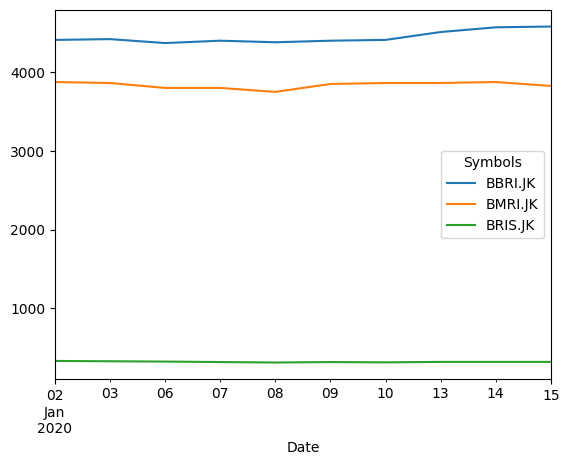

```python
stock['Close'].head(10).plot();
```

Kita dapat [menyesuaikan plot kami dengan style sheet](https://matplotlib.org/users/style_sheets.html) tetapi referensi praktis dapat dijangkau. Anda dapat mengganti 'default' dengan salah satu gaya yang tersedia dan menjalankan kembali kode plot untuk melihat gaya yang diterapkan.

```python
import matplotlib.pyplot as plt
print(plt.style.available)
plt.style.use('default')
```

```
['Solarize_Light2', '_classic_test_patch', '_mpl-gallery', '_mpl-gallery-nogrid', 'bmh', 'classic', 'dark_background', 'fast', 'fivethirtyeight', 'ggplot', 'grayscale', 'seaborn-v0_8', 'seaborn-v0_8-bright', 'seaborn-v0_8-colorblind', 'seaborn-v0_8-dark', 'seaborn-v0_8-dark-palette', 'seaborn-v0_8-d…
```

Karena metode `.plot()` dipanggil pada objek DataFrame, kita dapat memiliki DataFrame yang diindeks dengan beberapa kolom dan `plot` akan menanganinya menggunakan opsi defaultnya:

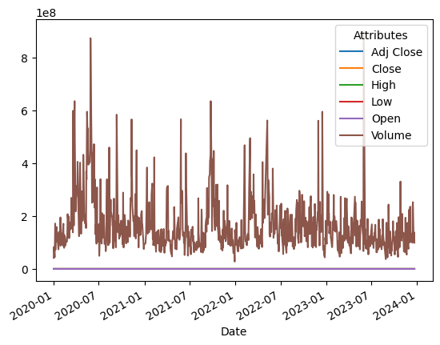

```python
bbri.plot();
```

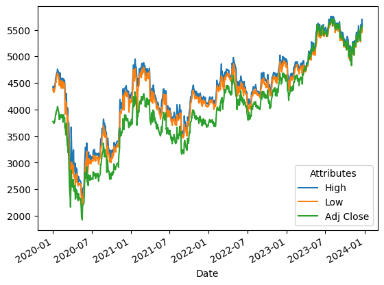

```python
bbri.loc[:, ['High', 'Low', 'Adj Close']].plot();
```

## Other Visualization

Visualisasi berikut hanya perlu menggunakan **satu** kolom:

- Data kategorik:
  - **`.plot(kind='bar')` untuk barplot (diagram batang)**
  - **`.plot(kind='barh')` untuk horizontal barplot**
  - **`.plot(kind='box')` untuk boxplot (five number summary)**
  - `.plot(kind='pie')` untuk pie chart
- Data numerik:
  - **`.plot(kind='hist')` untuk histogram**
  - `.plot(kind='density')` untuk density plot
  - `.plot(kind='area')` untuk area plot

Visualisasi berikut perlu menggunakan **dua** kolom:

- `.plot(kind='scatter')` untuk scatter plot
- `.plot(kind='hexbin')` untuk hexagonal bin plot

💡 Panduan untuk menentukan tipe visualisasi yang tepat: https://www.data-to-viz.com/

Silahkan mengacu referensi lengkapnya di [official documentation](https://pandas.pydata.org/pandas-docs/stable/reference/api/pandas.DataFrame.plot.html) untuk method `plot` apabila ingin eksplor visualisasi yang ada di luar lingkup course ini

# Group By

Membentuk ulang data adalah komponen penting dari setiap tahapan di data wrangling karena memungkinkan analis untuk "mengirimkan pesan" data ke dalam bentuk yang diinginkan untuk diproses lebih lanjut.

Teknik lain yang sama pentingnya adalah pengelompokan berdasarkan operasi. Analis yang memiliki pengalaman dengan SQL atau perangkat analisis data lainnya (misalnya `tidyverse` R) akan menganggap operasi grup sebagai strategi yang familier dalam banyak alur kerja yang banyak menganalisis.

Pertimbangkan DataFrame berikut:

```python
stock_adj = stock.stack()
stock_adj['Volume USD'] = stock_adj['Volume'] * stock_adj['Adj Close']
stock_adj = stock_adj.unstack()
stock_adj
```

| Attributes Symbols Date | Adj Close BBRI.JK | Adj Close BMRI.JK | Adj Close BRIS.JK | Close BBRI.JK | Close BMRI.JK | Close BRIS.JK | High BBRI.JK | High BMRI.JK | High BRIS.JK | Low BBRI.JK | Low ... | Low BRIS.JK | Open BBRI.JK | Open BMRI.JK | Open BRIS.JK | Volume BBRI.JK | Volume BMRI.JK | Volume BRIS.JK | Volume USD BBRI.JK | Volume USD BMRI.JK | Volume USD BRIS.JK |
| --- | --- | --- | --- | --- | --- | --- | --- | --- | --- | --- | --- | --- | --- | --- | --- | --- | --- | --- | --- | --- | --- |
| 2020-01-02 | 3,772.726 | 3,239.328 | 326.177 | 4,410.000 | 3,875.000 | 332.000 | 4,410.000 | 3,887.500 | 336.000 | 4,360.000 | ... | 330.000 | 4,400.000 | 3,837.500 | 330.000 | 41714100 | 37379800 | 1456400 | 157,375,882,916.675 | 121,085,428,320.947 | 475,044,585.657 |
| 2020-01-03 | 3,781.281 | 3,228.878 | 322.247 | 4,420.000 | 3,862.500 | 328.000 | 4,440.000 | 3,912.500 | 336.000 | 4,390.000 | ... | 326.000 | 4,420.000 | 3,875.000 | 334.000 | 82898300 | 70294600 | 4989600 | 313,461,787,446.875 | 226,972,716,839.746 | 1,607,885,657.007 |
| 2020-01-06 | 3,738.507 | 3,176.631 | 318.318 | 4,370.000 | 3,800.000 | 324.000 | 4,390.000 | 3,837.500 | 334.000 | 4,320.000 | ... | 320.000 | 4,360.000 | 3,825.000 | 328.000 | 44225100 | 61892000 | 6937900 | 165,335,827,872.876 | 196,608,067,369.141 | 2,208,455,440.582 |
| 2020-01-07 | 3,764.171 | 3,176.631 | 312.423 | 4,400.000 | 3,800.000 | 318.000 | 4,410.000 | 3,862.500 | 324.000 | 4,380.000 | ... | 316.000 | 4,410.000 | 3,862.500 | 324.000 | 103948100 | 70895600 | 6319400 | 391,278,438,345.825 | 225,209,185,370.898 | 1,974,324,582.458 |
| 2020-01-08 | 3,747.061 | 3,134.833 | 306.528 | 4,380.000 | 3,750.000 | 312.000 | 4,400.000 | 3,775.000 | 318.000 | 4,340.000 | ... | 312.000 | 4,380.000 | 3,775.000 | 318.000 | 171751200 | 105080600 | 4058800 | 643,562,271,192.773 | 329,410,184,669.629 | 1,244,136,031.702 |
| ... | ... | ... | ... | ... | ... | ... | ... | ... | ... | ... | ... | ... | ... | ... | ... | ... | ... | ... | ... | ... | ... |
| 2023-12-15 | 5,550.000 | 5,900.000 | 1,700.000 | 5,550.000 | 5,900.000 | 1,700.000 | 5,600.000 | 6,000.000 | 1,715.000 | 5,550.000 | ... | 1,700.000 | 5,575.000 | 5,950.000 | 1,710.000 | 252448800 | 142382200 | 12317700 | 1,401,090,840,000.000 | 840,054,980,000.000 | 20,940,090,000.000 |
| 2023-12-18 | 5,500.000 | 5,925.000 | 1,695.000 | 5,500.000 | 5,925.000 | 1,695.000 | 5,575.000 | 5,950.000 | 1,705.000 | 5,500.000 | ... | 1,670.000 | 5,575.000 | 5,850.000 | 1,690.000 | 102780900 | 101458600 | 12521500 | 565,294,950,000.000 | 601,142,205,000.000 | 21,223,942,500.000 |
| 2023-12-19 | 5,550.000 | 5,975.000 | 1,705.000 | 5,550.000 | 5,975.000 | 1,705.000 | 5,550.000 | 5,975.000 | 1,710.000 | 5,450.000 | ... | 1,690.000 | 5,450.000 | 5,950.000 | 1,700.000 | 135207300 | 40763200 | 5861900 | 750,400,515,000.000 | 243,560,120,000.000 | 9,994,539,500.000 |
| 2023-12-20 | 5,550.000 | 5,925.000 | 1,755.000 | 5,550.000 | 5,925.000 | 1,755.000 | 5,700.000 | 5,975.000 | 1,765.000 | 5,550.000 | ... | 1,710.000 | 5,700.000 | 5,900.000 | 1,710.000 | 138470900 | 65361000 | 39163500 | 768,513,495,000.000 | 387,263,925,000.000 | 68,731,942,500.000 |
| 2023-12-21 | 5,575.000 | 5,975.000 | 1,690.000 | 5,575.000 | 5,975.000 | 1,690.000 | 5,600.000 | 5,975.000 | 1,765.000 | 5,525.000 | ... | 1,680.000 | 5,550.000 | 5,950.000 | 1,765.000 | 99049600 | 50363900 | 25310000 | 552,201,520,000.000 | 300,924,302,500.000 | 42,773,900,000.000 |

970 rows × 21 columns

```python
volumeusd = stock_adj.xs(key='Volume USD',
                      level='Attributes',
                      axis=1)
volumeusd = volumeusd.round(2)
volumeusd
```

| Symbols Date | BBRI.JK | BMRI.JK | BRIS.JK |
| --- | --- | --- | --- |
| 2020-01-02 | 157,375,882,916.670 | 121,085,428,320.950 | 475,044,585.660 |
| 2020-01-03 | 313,461,787,446.880 | 226,972,716,839.750 | 1,607,885,657.010 |
| 2020-01-06 | 165,335,827,872.880 | 196,608,067,369.140 | 2,208,455,440.580 |
| 2020-01-07 | 391,278,438,345.830 | 225,209,185,370.900 | 1,974,324,582.460 |
| 2020-01-08 | 643,562,271,192.770 | 329,410,184,669.630 | 1,244,136,031.700 |
| ... | ... | ... | ... |
| 2023-12-15 | 1,401,090,840,000.000 | 840,054,980,000.000 | 20,940,090,000.000 |
| 2023-12-18 | 565,294,950,000.000 | 601,142,205,000.000 | 21,223,942,500.000 |
| 2023-12-19 | 750,400,515,000.000 | 243,560,120,000.000 | 9,994,539,500.000 |
| 2023-12-20 | 768,513,495,000.000 | 387,263,925,000.000 | 68,731,942,500.000 |
| 2023-12-21 | 552,201,520,000.000 | 300,924,302,500.000 | 42,773,900,000.000 |

970 rows × 3 columns

Perhatikan bagaimana bingkai data menunjukkan jumlah volume transaksi harian, misalnya kita ingin membandingkan rata-rata transaksi harian untuk BBRI.JK, BMRI.JK, dan BRIS.JK. Mari kita lakukan fungsi peleburan:

```python
volume_melted = volumeusd.melt()
volume_melted
```

|  | Symbols | value |
| --- | --- | --- |
| 0 | BBRI.JK | 157,375,882,916.670 |
| 1 | BBRI.JK | 313,461,787,446.880 |
| 2 | BBRI.JK | 165,335,827,872.880 |
| 3 | BBRI.JK | 391,278,438,345.830 |
| 4 | BBRI.JK | 643,562,271,192.770 |
| ... | ... | ... |
| 2905 | BRIS.JK | 20,940,090,000.000 |
| 2906 | BRIS.JK | 21,223,942,500.000 |
| 2907 | BRIS.JK | 9,994,539,500.000 |
| 2908 | BRIS.JK | 68,731,942,500.000 |
| 2909 | BRIS.JK | 42,773,900,000.000 |

2910 rows × 2 columns

Misalkan kita ingin membandingkan rata-rata volume transaksi antara masing-masing harga saham. Rata-rata, manakah dari 3 saham tersebut yang memiliki rata-rata volume transaksi harian tertinggi?

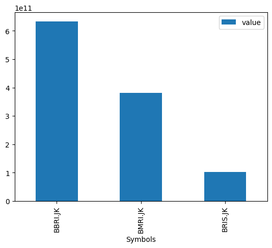

```python
volume_melted.groupby(['Symbols']).mean().plot.bar();
```

## Visualisasi Barchart untuk Perbandingan

Katakanlah kita ingin membandingkan rata-rata volume penjualan harian dari perusahaan-perusahaan tersebut. Untuk melakukan itu, kita perlu mengekstrak atribut volume dari kerangka data kita, dan menjalankan fungsi leleh:

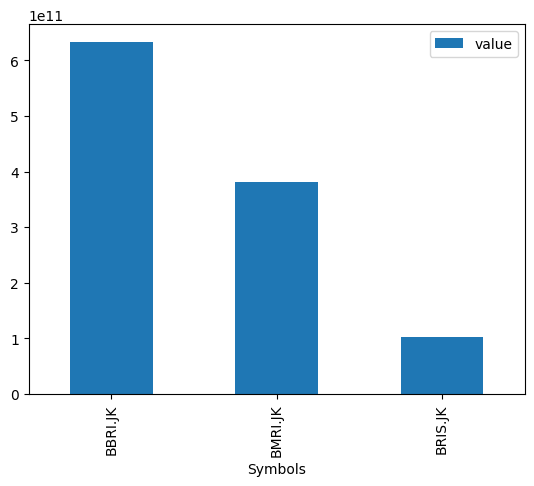

```python
volume_melted.groupby('Symbols').mean().plot.bar();
```

Jika kita membandingkan visualisasi dengan angka numerik, akan jauh lebih mudah untuk membandingkan volume rata-rata setiap saham. Sekarang mari kita pertimbangkan kerangka data berikut ini:

```python
bbri = stock.xs('BBRI.JK', level='Symbols', axis=1)
bbri = bbri.round(2)
bbri['Close_Diff'] = bbri['Close'].diff()
bbri['Weekday'] = bbri.index.day_name()
bbri
```

| Attributes Date | Adj Close | Close | High | Low | Open | Volume | Close_Diff | Weekday |
| --- | --- | --- | --- | --- | --- | --- | --- | --- |
| 2020-01-02 | 3,772.730 | 4,410.000 | 4,410.000 | 4,360.000 | 4,400.000 | 41714100 | NaN | Thursday |
| 2020-01-03 | 3,781.280 | 4,420.000 | 4,440.000 | 4,390.000 | 4,420.000 | 82898300 | 10.000 | Friday |
| 2020-01-06 | 3,738.510 | 4,370.000 | 4,390.000 | 4,320.000 | 4,360.000 | 44225100 | -50.000 | Monday |
| 2020-01-07 | 3,764.170 | 4,400.000 | 4,410.000 | 4,380.000 | 4,410.000 | 103948100 | 30.000 | Tuesday |
| 2020-01-08 | 3,747.060 | 4,380.000 | 4,400.000 | 4,340.000 | 4,380.000 | 171751200 | -20.000 | Wednesday |
| ... | ... | ... | ... | ... | ... | ... | ... | ... |
| 2023-12-15 | 5,550.000 | 5,550.000 | 5,600.000 | 5,550.000 | 5,575.000 | 252448800 | 0.000 | Friday |
| 2023-12-18 | 5,500.000 | 5,500.000 | 5,575.000 | 5,500.000 | 5,575.000 | 102780900 | -50.000 | Monday |
| 2023-12-19 | 5,550.000 | 5,550.000 | 5,550.000 | 5,450.000 | 5,450.000 | 135207300 | 50.000 | Tuesday |
| 2023-12-20 | 5,550.000 | 5,550.000 | 5,700.000 | 5,550.000 | 5,700.000 | 138470900 | 0.000 | Wednesday |
| 2023-12-21 | 5,575.000 | 5,575.000 | 5,600.000 | 5,525.000 | 5,550.000 | 99049600 | 25.000 | Thursday |

970 rows × 8 columns

Misalkan kita ingin membandingkan `Close_Diff` antara setiap Hari Kerja; Rata-rata, apakah hari Selasa mencatat perbedaan yang lebih tinggi antara harga Penutupan saham BRI dibandingkan hari Kamis?

```python
bbri.groupby('Weekday').mean(numeric_only=True)
```

| Attributes Weekday | Adj Close | Close | High | Low | Open | Volume | Close_Diff |
| --- | --- | --- | --- | --- | --- | --- | --- |
| Friday | 4,049.947 | 4,348.636 | 4,400.580 | 4,298.007 | 4,351.735 | 170,257,775.441 | 1.634 |
| Monday | 4,029.579 | 4,330.059 | 4,382.903 | 4,283.034 | 4,341.923 | 147,363,182.086 | -8.090 |
| Thursday | 4,021.308 | 4,325.322 | 4,379.851 | 4,278.062 | 4,332.870 | 166,182,807.247 | -0.457 |
| Tuesday | 4,033.065 | 4,330.981 | 4,386.888 | 4,284.111 | 4,332.204 | 163,620,687.776 | 9.430 |
| Wednesday | 4,030.649 | 4,331.024 | 4,384.109 | 4,282.291 | 4,338.537 | 169,151,324.725 | 3.370 |

Now to create the same bar chart using `plot` function:

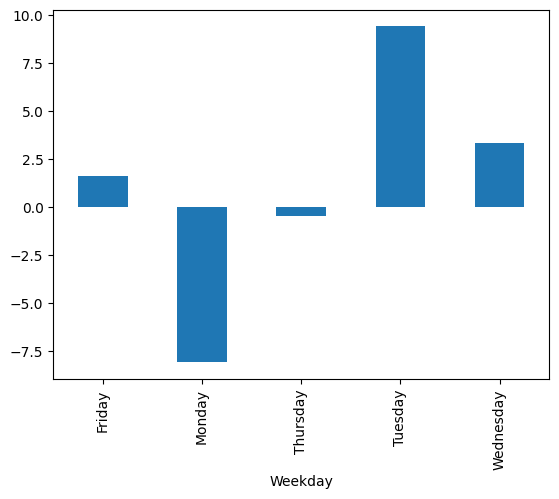

```python
bbri.groupby('Weekday').mean(numeric_only=True)['Close_Diff'].plot.bar();
```

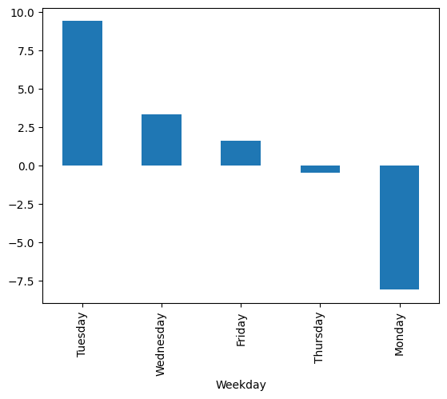

```python
# berdasarkan urutan nilai terbesar - terkecil
bbri.groupby('Weekday').mean(numeric_only=True)['Close_Diff'].sort_values(ascending=False).plot.bar();
```

Kita juga dapat membuat indeks yang diurutkan secara manual dengan menentukan urutan hari itu.

```python
wday = ["Monday", "Tuesday", "Wednesday", "Thursday", "Friday"]

bbri_wday = bbri.groupby('Weekday').mean(numeric_only=True)['Close_Diff']
```

```python
bbri_wday.index = pd.CategoricalIndex(bbri_wday.index,\
                                      categories=wday,\
                                      ordered=True)
```

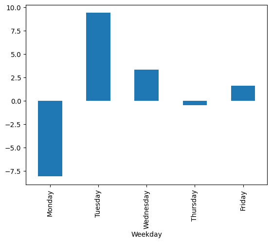

```python
bbri_wday.sort_index().plot.bar();
```

## Menggunakan Barchart Group

Pertama, lihat `harga penutupan` dan pastikan tidak ada nilai yang hilang pada data. Jika sudah, isi dengan cara yang sesuai

```python
closingprice = stock['Close']
closingprice.head()
```

| Symbols Date | BBRI.JK | BMRI.JK | BRIS.JK |
| --- | --- | --- | --- |
| 2020-01-02 | 4,410.000 | 3,875.000 | 332.000 |
| 2020-01-03 | 4,420.000 | 3,862.500 | 328.000 |
| 2020-01-06 | 4,370.000 | 3,800.000 | 324.000 |
| 2020-01-07 | 4,400.000 | 3,800.000 | 318.000 |
| 2020-01-08 | 4,380.000 | 3,750.000 | 312.000 |

```python
## Write your solution code here
# Buat kolom baru bernama 'Month', yang menunjukkan nama bulan pada tanggal tersebut

closingprice.loc[:, 'Month'] = closingprice.index.month_name()
```

```python
closingprice
```

| Symbols Date | BBRI.JK | BMRI.JK | BRIS.JK | Month |
| --- | --- | --- | --- | --- |
| 2020-01-02 | 4,410.000 | 3,875.000 | 332.000 | January |
| 2020-01-03 | 4,420.000 | 3,862.500 | 328.000 | January |
| 2020-01-06 | 4,370.000 | 3,800.000 | 324.000 | January |
| 2020-01-07 | 4,400.000 | 3,800.000 | 318.000 | January |
| 2020-01-08 | 4,380.000 | 3,750.000 | 312.000 | January |
| ... | ... | ... | ... | ... |
| 2023-12-15 | 5,550.000 | 5,900.000 | 1,700.000 | December |
| 2023-12-18 | 5,500.000 | 5,925.000 | 1,695.000 | December |
| 2023-12-19 | 5,550.000 | 5,975.000 | 1,705.000 | December |
| 2023-12-20 | 5,550.000 | 5,925.000 | 1,755.000 | December |
| 2023-12-21 | 5,575.000 | 5,975.000 | 1,690.000 | December |

970 rows × 4 columns

Setelah kita memiliki kolom `Month`, mari kelompokkan berdasarkan Bulan dan lihat DataFrame yang dihasilkan

```python
average_closing = closingprice.groupby('Month').mean()
average_closing
```

| Symbols Month | BBRI.JK | BMRI.JK | BRIS.JK |
| --- | --- | --- | --- |
| April | 4,081.733 | 3,475.367 | 1,419.053 |
| August | 4,334.204 | 4,088.415 | 1,581.646 |
| December | 4,610.789 | 4,328.618 | 1,662.105 |
| February | 4,572.727 | 4,013.961 | 1,540.818 |
| January | 4,467.738 | 3,941.964 | 1,563.738 |
| July | 4,135.952 | 3,672.857 | 1,502.476 |
| June | 4,199.750 | 3,603.344 | 1,307.487 |
| March | 4,385.581 | 3,847.384 | 1,532.256 |
| May | 4,156.159 | 3,627.935 | 1,408.116 |
| November | 4,505.000 | 4,430.172 | 1,576.552 |
| October | 4,300.305 | 4,316.921 | 1,546.829 |
| September | 4,194.843 | 4,051.366 | 1,528.023 |

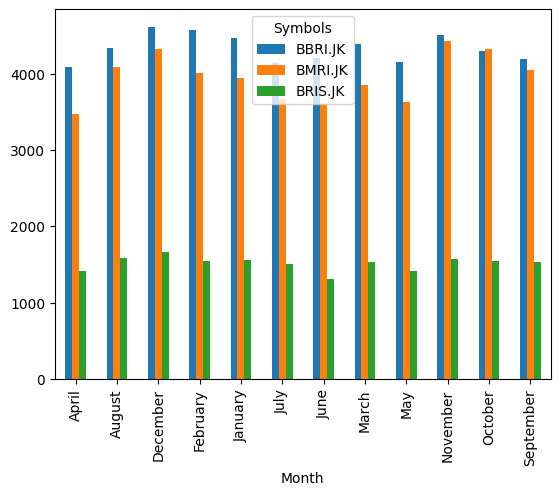

```python
average_closing.sort_index().plot.bar();
```

Namun, jika ingin menyusun ulang bulannya, kita harus menetapkan indeks sebagai nilai kategorikal yang diurutkan (Lihat materi Analisis Data Eksplorasi jika Anda perlu mengingatnya).

```python
months= ['January', 'February', 'March', 'April', 'May', 'June', 'July', 'August', 'September', 'October', 'November', 'December']
```

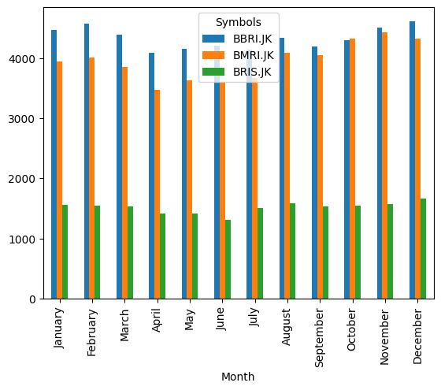

```python
average_closing.index = pd.CategoricalIndex(average_closing.index,\
                                            categories=months,\
                                            ordered=True)

average_closing.sort_index().plot.bar();
```

Referensi lengkap ke [dokumentasi resmi](https://pandas.pydata.org/pandas-docs/stable/reference/api/pandas.DataFrame.plot.html) tentang metode ini berada di luar cakupan buku pelajaran ini, tapi layak untuk dibaca.

## Menggabungkan `agg` dan `groupby`

Sejauh ini, kami telah menjelajahi beberapa perangkat agregasi panda, seperti:

- `pd.crosstab()`
- `pd.pivot_table()`

Dalam bab ini, kita akan menjelajahi alat agregasi panda lainnya:

- agregasi `groupby`.

**Pembahasan:**

(`pivot_table` & `pd.crosstab` kesetaraan)

Metode `pivot_table` dan fungsi `crosstab` keduanya dapat menghasilkan hasil yang sama persis dengan bentuk yang sama. Keduanya berbagi parameter; `indeks`, `kolom`, `nilai`, dan `aggfunc`.

Perbedaan utama yang terlihat adalah `crosstab` adalah sebuah fungsi dan bukan metode DataFrame. Ini memaksa Anda untuk menggunakan kolom sebagai Seri dan bukan nama string untuk parameternya.

1. Misalkan Anda ingin membandingkan jumlah total transaksi selama Hari Kerja setiap periode kuartal. Buat `pivot_table` yang menyelesaikan masalah!
2. Cobalah untuk mereproduksi hasil yang sama dengan menggunakan `crosstab`
3. Bagaimana jika, alih-alih membandingkan total transaksi, Anda ingin membandingkan total pendapatan dari periode yang sama? Gunakan `pivot_table` dan `crosstab` sebagai solusinya. Diskusikan dengan teman anda, metode mana yang lebih relevan dalam kasus ini?

Perhatikan kelompok berikut berdasarkan operasi:

```python
stock.stack().reset_index().groupby('Symbols').mean(numeric_only=True)
```

| Attributes Symbols | Adj Close | Close | High | Low | Open | Volume |
| --- | --- | --- | --- | --- | --- | --- |
| BBRI.JK | 4,029.681 | 4,330.575 | 4,384.187 | 4,282.450 | 4,336.708 | 163,307,060.979 |
| BMRI.JK | 3,704.355 | 3,957.539 | 4,007.769 | 3,908.425 | 3,960.150 | 106,337,189.669 |
| BRIS.JK | 1,498.105 | 1,516.107 | 1,553.779 | 1,487.457 | 1,518.201 | 66,685,960.537 |

```python
stock.stack().reset_index().groupby('Symbols').agg({
    'Close': 'mean',
    'High': 'max',
    'Low': 'min'
})
```

| Attributes Symbols | Close | High | Low |
| --- | --- | --- | --- |
| BBRI.JK | 4,330.575 | 5,750.000 | 2,160.000 |
| BMRI.JK | 3,957.539 | 10,400.000 | 1,830.000 |
| BRIS.JK | 1,516.107 | 3,980.000 | 135.000 |

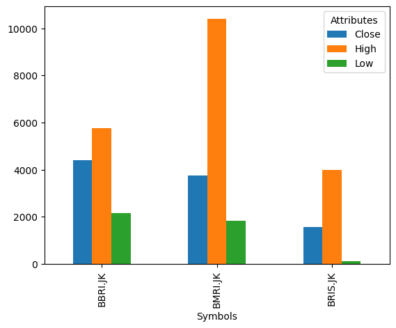

```python
stock.stack().reset_index().groupby('Symbols').agg({
    'Close': 'median',
    'High': 'max',
    'Low': 'min'
}).plot.bar();
```

**Knowledge Check:** Menggunakan `plot`

Pertimbangkan kerangka data berikut:

```python
import datetime

stock['YearMonth'] = pd.to_datetime(stock.index.date).to_period('M')
monthly_closing = stock.groupby('YearMonth').mean().loc[:,['Close','Low', 'High']]
monthly_closing.head()
```

| Attributes Symbols YearMonth | Close BBRI.JK | Close BMRI.JK | Close BRIS.JK | Low BBRI.JK | Low BMRI.JK | Low BRIS.JK | High BBRI.JK | High BMRI.JK | High BRIS.JK |
| --- | --- | --- | --- | --- | --- | --- | --- | --- | --- |
| 2020-01 | 4,550.000 | 3,847.727 | 317.909 | 4,513.182 | 3,805.114 | 314.727 | 4,576.818 | 3,892.045 | 322.909 |
| 2020-02 | 4,477.500 | 3,862.500 | 296.900 | 4,439.500 | 3,807.500 | 293.000 | 4,528.500 | 3,900.000 | 303.800 |
| 2020-03 | 3,440.952 | 2,916.667 | 196.857 | 3,362.857 | 2,847.976 | 187.286 | 3,615.714 | 3,025.238 | 212.810 |
| 2020-04 | 2,785.714 | 2,260.238 | 194.714 | 2,727.143 | 2,196.190 | 191.095 | 2,878.095 | 2,337.738 | 202.286 |
| 2020-05 | 2,530.625 | 2,045.312 | 267.500 | 2,468.750 | 2,004.062 | 254.625 | 2,590.000 | 2,096.875 | 284.500 |

Manakah dari berikut ini yang merupakan plot yang sesuai untuk digunakan?

- Line plot -> .plot()
- Scatter plot -> .plot.scatter(x=? , y=?)
- Bar plot -> .plot.bar()
- Box plot -> .plot.box()

```python
## Your code below
```